# Homework 3 - Group 46

Name and Surname: Alessandra Colaiocco - ID: 1843714 - Email: colaiocco.1843714@studenti.uniroma1.it Name and Surname: Gabriele Parisini - ID: 1964381 - Email: parisini.1964381@studenti.uniroma1.it

2024-01-27

# Game Theory and Shapley Value

## Introduction

A *game* (in *game theory*) is an abstract mathematical model of a scenario in which *agents* (or *players*) interact. When we’re dealing with a game, we’re interested in those features of the scenario that are relevant to the decisions of the players.  
In this homework we’re focusing on **cooperative games**, which are games populated by a set $\mathcal{P} = \{1,...,p\}$ of players (or *grand coalition*) which are able to form *coalitions* (subsets of the “grand” one).  
To continue further in the explanation, we would need to define the *characteristic function game*:

**Definition 1.** A characteristic function game $G$ is given by a pair $(\mathcal{P},\nu)$, where $\mathcal{P} = \{1,...,p\}$ is a non-empty set and $\nu: 2^{\mathcal{P}}\mapsto\mathbb{R}$ is a **characteristic function** which maps every coalition $C \subseteq\mathcal{P}$ to a real number $\nu(C)$ (which is referred to as the **value of the coalition $C$**).

It’s crucial to understand that the characteristic function game assigns a value to a coalition as a whole, **not telling how the coalition value should be divided among the members of the coalition itself.** How to divide the coalition value is a **fundamental question** in cooperative game theory.  
Another key problem in game theory is to try to understand what the outcomes of a game will be. An *outcome* of a game $G$ consists of two parts:

1. A **coalition structure**, which is a partition of the gran coalition into coalitions $\big(CS = \{C_1,...,C_m\}\big)$
2. A **payoff vector** $\mathbb{x} = (x_1,...,x_p)$ associated to the coalition structure which distributes the value $\nu(C_j)$ of each coalition among its members. All its entries must be non negative and the sum of entries for players belonging to the same coalition must be lower or equal than the coalition value.

As one can imagine, **not all outcomes are equally desirable**. An outcome that pushes all agents together is (typically) preferable to an outcome that some agents want to deviate from and an outcome that shares the payoff in a fair way is desirable.  
There are two criteria to evaluate an outcome:

1. **Fairness**: how well each agent’s payoff reflects its contribution.
2. **Stability**: what are the incentives for the agents to stay in the coalition structure.

We’ll focus on the **Shapley Value** that belongs to a family of solution concepts which takes account mainly of the fairness of an outcome. It’s defined with respect to the grand coalition: it defines a way of distributing the value $\nu(\mathcal{P})$ that could be obtained by the *gran coalition* (so, in the case where all players are in the same coalition), and it is based on the intuition that **the payment that each agent receives should be proportional to his contribution.**  
The initial idea is, given a **fixed ordering** of agents, to pay each one of them **according to how much is the increase in the value of the coalition formed by its precedessors**. The problem is that agents that play symmetric roles may receive different payoffs depending on their position in the ordering.  
The Shapley Value removes the dependence on the agents ordering by **averaging over all possible orderings (or permutations) of the players.**  
Some additional notation is needed to formally define the Shapley Value:

1. $S_\pi(j)$ the set of all predecessors of player $j$ in $\pi$ defined as $S_\pi(j)= \{r \in \mathcal{P} \ \text{such tath} \ \pi(r) < \pi(j)\}$ where $\Pi_{\mathcal{P}}$ is the set of all permutations of $\mathcal{P}$ and $\pi$ is a specific permutation.
2. **The marginal contribution** of an agent $j$ with respect to a permutation $\pi$ in a game $G = (\mathcal{P}, \nu)$, that is
   $$\Delta_\pi^G(j) = \nu(S_\pi(j) \cup \{j\} ) -
   \nu(S_\pi(j))$$
   and measures how much player $j$ increases the value of the coalition consisting of its predecessor in $\pi$.

Now, we can define the **Shapley Value** $\psi^G(j)$ (for a game $G$ and a player $j$) as **the average marginal contribution of the player $j$**, where the average is taken **over all permutations** of the player set (assumed to be **all equally likely**):

$$\begin{align}
\psi^G(j) = \mathbb{E}_{\pi}\left(\Delta_{\pi}^{G}(j)\right) =
\frac{1}{p!} \sum_{\pi \in \Pi_{\mathcal{P}}} \Delta_{\pi}^{G}(j) =
\sum_{C : j \notin C}
\frac{(\#C)!(p-1-\#C)!}{p!}\left(\nu(C\cup\{j\})-\nu(C)\right)
\end{align}$$

Please note that the marginal contributions $\Delta_{\pi}^{G}(j)$ are of the form $\nu(C\cup\{j\})-\nu(C)$, where $C$ is a coalition not containing the player $j$. Also, there are $(\#C)!$ possible orderings of $C$ and $(p-1-\#C)!$ possible orderings of $\mathcal{P}\setminus(C\cup\{j\})$.  
It is shown that the Shapley Value is **the only payoff division scheme** that has all these four properties:

- **Efficiency**: $\sum_{j} \psi^G(j) = \nu(\mathcal{P})$.
- **Dummy player**: if player $j$ is dummy (i.e., $\nu(C \cup \{j\}) = \nu(C)$ for any coalition $C$), then $\psi^G(j) = 0$.
- **Symmetry**: if $j_1$ and $j_2$ are symmetric players (i.e., $\nu(C \cup \{j_1\}) = \nu(C \cup \{j_2\})$ for any coalition $C$), then $\psi^{G}(j_1) = \psi^{G}(j_2)$.
- **Additivity**: given any two characteristic function games $G_1 = (\mathcal{P},\nu_1)$ and $G_2 = (\mathcal{P},\nu_2)$, and their sum $G^+ = (\mathcal{P},\nu_1 + \nu_2)$,
  $$\psi^+(j) = \psi^G_1(j) +
  \psi^G_2(j) \text{ for all } j \in \mathcal{P}.$$

In **simple games** (monotone and with characteristic function which only takes values 0 and 1), the Shapley Value measures the *power of the player*, the probability that it can influence the outcome of the game. To be more precise, it is the **probability that the player $j$ turns a losing coalition into a winning one.**

The last important concept to stress is that the **Shaley value** can be used to determine the importance of different variables (**covariates**) in a supervised learning problem. It casts the problem as a game where the **covariates are players** and the **measure of fit is the characteristic function.** **The value of a coalition of covariates is the negative expected squared difference between the actual and predicted outcomes.** The Shapley value represents the **average contribution of a covariate to the predictive accuracy across all possible combinations of covariates.**

An important remark regarding the Shapley value is that while it offer a comprehensive importance measure, **it isn’t without limitations**, such as being affected by covariate correlation.

## Exercise 1: Get a better understanding of Games and Shapley

In this first exercise, given a game with 3 player, **Antwohnette (A), BadellPadel (B) and Chumbawamba (C)** we are asked to complete the definition of the **characteristic function game, $\nu$**, and then to calculate the **Shapley value**.

Taking into account the definition of the **characteristic function game $\nu$** above we can claim that:

- $\mathcal{P}=\{A,B,C\}$ is the set of our agents (our players).
- $\nu: 2^\mathcal{P} \rightarrow \mathbb{R}$ is our **characteristic function** that we have to find.

From the text of the exercise we know that:

- $\nu(A)=\nu(B)=\nu(C)=0$
- $\nu(ABC)=4$

Now we have to find the other value of $\nu$ associated with the others combinations of our players and so we have to find $\nu(AB)$, $\nu(AC)$ and $\nu(BC)$.  
Let’s start with the definition of our $\nu$ that is **the numbers of hours potentially saved by well organized coalition**, so in order to get our values we have to find the hours in which each pair of players saves time by working together and thus we must numerically count the hours in which our players are dedicated to solving the homework at the same time. From the setup of the game we know that:

- **Player A works from 14:00 to 17:00**
- **Player B works from 11:00 to 16:00**
- **Player C works from 9:00 to 13:00**

An so we can claim that:

- $\nu(AB)=2$, because the hours in which both A and B are dedicated to solving the homework are exactly 2, from 14:00 to 16:00.
- $\nu(AC)=0$, because Because A and C never have hours in common to work together on the homework and thus ‘team up’.
- $\nu(BC)=2$, because the hours in which both A and B are dedicated to solving the homework are exactly 2, from 11:00 to 13:00.

So to summarize all the calculations in a table we have:

$$\begin{array}{c|ccc}
\text{Permutation} & \text{Player A} & \text{Player B} &
\text{Player C} \\ \hline
ABC & 0 & 2 & 2 \\
ACB & 0 & 4 & 0 \\
BAC & 2 & 0 & 2 \\
BCA & 2 & 0 & 2 \\
CAB & 0 & 4 & 0 \\
CBA & 2 & 2 & 0 \\ \hline
\text{TOTAL VALUE} & 6 & 12 & 6 \\
\end{array}$$

At this point, we have everything to calculate the **Shapley value**. First of all, remember that the **Shapley value** of each player $j$, where $j \in \{A,B,C\}$ is the function that calculates the average marginal contribution of each players, taken over all permutations of the player-set, in particular we have:
$$\psi^G(j)=\mathbb{E}[\Delta_\pi^G(j)]=\frac{1}{p!}\sum_{\pi
\in \Pi_\mathcal{P}} \Delta_\pi^G(j)$$
In our scenario we have $p!=3!=6$ permutations and for each player we have:
- **Player A:** $\sum_{\pi \in \Pi_\mathcal{P}} \Delta_\pi^G(A)=6$
- **Player B:** $\sum_{\pi \in \Pi_\mathcal{P}} \Delta_\pi^G(B)=12$
- **Player C:** $\sum_{\pi \in \Pi_\mathcal{P}} \Delta_\pi^G(C)=6$

So in the end we can claim that:
$$\psi^G(A)=\frac{6}{6}=1 \\
\psi^G(B)=\frac{12}{6}=2 \\ \psi^G(C)=\frac{6}{6}=1$$
**If we read this value in the context of the exercise they suggest to us that Antwohnette and Chumbawamba have potentially saved 1 hour by well organized coalition, instead BadellPadel 2 hours.**

## Exercise 2: A statistical application of the Shapley value to finance

In this exercise it is asked to leverage the theory above in a financial context. There is a **portfolio of $p$ stocks** whose returns are modeled by a set of random variables $\{X_1,...,X_p\}$. The **utility function** is defined as follows:
$$\begin{align}
U_{\omega}(X) = \mathbb{E}(X) - \omega\cdot\mathbb{V}ar(X) \quad
\text{for some weight} \quad \omega > 0
\end{align}$$
It’s basically a linear combination of the average return and volatility of the portfolio. The problem consists in deciding how to allocate the capital among all of the stocks: intuitively, it would be good that the allocation is proportional to the asset’s contribution to the total utility $U_{\omega}(\sum_{j=1}^pX_j)$.
We now define this setting in a **cooperative game theory prespective**. Let the assets be the players and let $C$ be any coalition of them, with $R_C = \sum_{j\in C}X_j$ being their return. For any $C\subset\mathcal{P}$ we define the characteristic function as follows:
$$\begin{align}
\nu(C) = U_{\omega}(R_C) = \mathbb{E}(R_C) -
\omega\cdot\mathbb{V}ar(R_C) = \nu_{\mathbb{E}}(C) -
\omega\cdot\nu_{\mathbb{V}}(C)
\end{align}$$
Hence, the game we’re defining $(G = (\mathcal{P},\nu))$ is a linear combination of two other games: $G_{\mathbb{E}} = (\mathcal{P},\nu_{\mathbb{E}})$ and $G_{\mathbb{V}} = (\mathcal{P},\nu_{\mathbb{V}})$.
Since our goal is to allocate the capital proportionally to the contribution given to the total utility, the Shapley Value turns out to be suitable and simple.
By the **additivity of the Shapley Value** we get that:
$$\begin{align}
\psi^G(j) = \psi^G_{\mathbb{E}}(j) - \omega\cdot \psi^G_{\mathbb{V}}(j)
\end{align}$$
By the **linearity of expectation**, the first term is:
$$\begin{align}
\psi^G_{\mathbb{E}}(j) = \mathbb{E}(X_j)
\end{align}$$
While the second term, after elementary manipulations, turns out to be:
$$\begin{align}
\psi^G_{\mathbb{V}}(j) = \mathbb{C}ov(X_j,R_{\mathcal{P}})
\end{align}$$
In conclusion, after picking a suitable weight $\omega > 0$, the Shapley allocation to each stock is given by:
$$\begin{align}
\psi^G(j) = \mathbb{E}(X_j) -
\omega\cdot\mathbb{C}ov(X_j,R_{\mathcal{P}}) = \mathbb{E}(X_j) -
\omega\cdot\sum_{r=1}^p\mathbb{C}ov(X_j,X_r)
\end{align}$$
In other words, the **Shapley Value, used to allocate capital, is a population quantity to be estimated**. By taking a look at the formula, it can be noticed that we would need to study the marginal correlation graph among some standard measure of stock *relative performance* (which may be calculated starting from the *daily closing prices* of the stocks).
In practice, we need to:

- Select a sensibly sized portfolio of $p$ stocks and take their *closing price* from **January 1, 2020 till the end of 2023.**
- From the closing prices $c_{t,j}$ (stock $j$ on day $t$), we have to **compute their relative log-returns** $x_{t,j} = \log(c_{t,j}/c_{t-1,j})$.
- By setting each stock as a node, we have to **estimate the Pearson-based correlation graph over stocks**, by treating the instances $\{x_{t,j}\}_t$ as independent samples (even though they’re not). We place an undirected edge between stocks $j_1$ and $j_2$ only if the CI for the Pearson correlation doesn’t intersect the interval $[-\tau,\tau]$, where $\tau$ is an arbitrary threshold.
- After **properly visualizing the graph**, we have to draw some conclusions based on the decisions made along the way.
- Finally, we have to **provide bootstrapped confidence intervals for the Shapley Values** of the stocks in our portfolio and comment the results based on the choices we’ve made.

As we said, the first important thing is to get the data: we have decided to select from the **Global Industry Classification Standard (GICS)** sectors **10 stocks**, picking a pair of stock for each of the following sectors: **Energy, Information Technology, Consumer Discrectionary, Healthcare and Financials.** The selected stocks are the following:

- **Eni:** it is an italian multinational oil and gas company, headquartered in Rome, involved in oil and natural gas exploration, field development, production, as well as in the supply, trading, and shipping of natural gas, LNG, electricity, and fuels.
- **Sumiseki Holdings:** it is a japanese company primarily engaged in the coal and carbon-related business, including the production and sale of charcoal and other carbon products, with a focus on environmental sustainability and energy efficiency.
- **Apple:** it is an american multinational technology company headquartered in Cupertino, California, that designs, manufactures, and markets consumer electronics, computer software, and online services, best known for products like the iPhone, iPad, and Mac computers.
- **Microsoft:** it is an american multinational technology company that develops, manufactures, licenses, supports, and sells computer software, consumer electronics, and personal computers and services, notably the Windows operating systems, the Microsoft Office suite, and the Xbox gaming consoles.
- **McDonalds:** it is one of the most famous fast food company. It is the world’s largest restaurant chain by revenue, serving over 69 million customers daily in over 100 countries across 37,855 outlets as of 2018.
- **Carrefour:** it is a french multinational retail corporation operating one of the largest chain of hypermarkets, groceries and convenience stores in the world. As of 2020, it operates in more than 30 countries.
- **Bayer:** it is a german multinational pharmaceutical and life sciences company and one of the largest pharmaceutical companies in the world. Its areas of business include human and veterinary pharmaceuticals, agricultural chemicals, seeds, and biotechnology products.
- **Cipla:** it is an indian multinational pharmaceutical and biotechnology company that primarily develops medicines to treat respiratory, cardiovascular disease, arthritis, diabetes, weight control, depression and other medical conditions.
- **BlackRock:** it is an american global investment management corporation based in New York City. Founded in 1988, initially as a risk management and fixed income institutional asset manager, BlackRock is the world’s largest asset manager, with $8.67 trillion in assets under management as of January 2021.
- **JPMorgan:** it is an american multinational investment bank and financial services holding company, it is the largest bank in the United States, and the world’s by total assets, considered to be a major provider of financial services, and according to Forbes magazine it is the world’s most valuable bank by market capitalization.

**We’ve decided to choose 2 stocks from 5 different sectors to diversify the portfolio**, so that we could compare stocks in the same sector but especially the correlation that may exist between stocks in different sectors, trying to understand why there is a correlation and thus interpret the data we get. In addition to diversification by different sectors, we also decided to diversify according to the country where these stocks are based (we have 3 European stocks, 5 American stocks and 2 Asian stocks), so that we could also understand whether the geographical position affects the relationship between the stocks.

Once we’ve chosen the stocks to work with, we got the data of open and close prize from the **January 1, 2020 till the end of 2023.** We had to do a bit of preprocessing to have a set of data to work with because we’ve realized that we had *different length series, as the opening days of some stocks were different from the others. We’ve decided to fill eventual holidays to prevent this from happening* and once we had consistent data we’ve calculated the **realtive log-returns for each stock.**

```r
# PREPROCESSING PART 1
# Get stocks data with the library 'tseries'
library(tseries, quietly = T)
```

```r
options("getSymbols.warning4.0" = FALSE)

# Pull data about the chosen stocks
eni <- get.hist.quote(instrument="E", start="2020-01-01", end="2023-12-31", quote= c("Open","Close"), provider="yahoo", drop=TRUE, quiet = TRUE)

smh <- get.hist.quote(instrument="1514.T", start="2020-01-01", end="2023-12-31", quote= c("Open","Close"), provider="yahoo", drop=TRUE, quiet = TRUE)

aapl <- get.hist.quote(instrument="AAPL", start="2020-01-01", end="2023-12-31", quote= c("Open","Close"), provider="yahoo", drop=TRUE, quiet = TRUE)

micro <- get.hist.quote(instrument="MSFT", start="2020-01-01", end="2023-12-31", quote= c("Open","Close"), provider="yahoo", drop=TRUE, quiet = TRUE)

mcd <- get.hist.quote(instrument="MCD", start="2020-01-01", end="2023-12-31", quote= c("Open","Close"), provider="yahoo", drop=TRUE, quiet = TRUE)

carf <- get.hist.quote(instrument="CA.PA", start="2020-01-01", end="2023-12-31", quote= c("Open","Close"), provider="yahoo", drop=TRUE, quiet = TRUE)

bay <- get.hist.quote(instrument="BAYN.DE", start="2020-01-01", end="2023-12-31", quote= c("Open","Close"), provider="yahoo", drop=TRUE, quiet = TRUE)

cipla <- get.hist.quote(instrument="CIPLA.NS", start="2020-01-01", end="2023-12-31", quote= c("Open","Close"), provider="yahoo", drop=TRUE, quiet = TRUE)

brk <- get.hist.quote(instrument="BLK", start="2020-01-01", end="2023-12-31", quote= c("Open","Close"), provider="yahoo", drop=TRUE, quiet = TRUE)

jpm <- get.hist.quote(instrument="JPM", start="2020-01-01", end="2023-12-31", quote= c("Open","Close"), provider="yahoo", drop=TRUE, quiet = TRUE)

# Fill eventual missing dates (probably holidays) to prevent different series' length
eni <- zoo::na.approx(eni, xout = seq(start(smh), end(eni), by = "day"), method = "constant")
smh <- zoo::na.approx(smh, xout = seq(start(smh), end(smh), by = "day"), method = "constant")
aapl <- zoo::na.approx(aapl, xout = seq(start(smh), end(aapl), by = "day"), method = "constant")
micro <- zoo::na.approx(micro, xout = seq(start(smh), end(micro), by = "day"), method = "constant")
mcd <- zoo::na.approx(mcd, xout = seq(start(smh), end(mcd), by = "day"), method = "constant")
carf <- zoo::na.approx(carf, xout = seq(start(smh), end(carf), by = "day"), method = "constant")
bay <- zoo::na.approx(bay, xout = seq(start(smh), end(bay), by = "day"), method = "constant")
cipla <- zoo::na.approx(cipla, xout = seq(start(smh), end(cipla), by = "day"), method = "constant")
brk <- zoo::na.approx(brk, xout = seq(start(smh), end(brk), by = "day"), method = "constant")
jpm <- zoo::na.approx(jpm, xout = seq(start(smh), end(jpm), by = "day"), method = "constant")

# Compute their relative log-returns
eni$y = diff(log(eni$Close))
smh$y = diff(log(smh$Close))
aapl$y = diff(log(aapl$Close))
micro$y = diff(log(micro$Close))
mcd$y = diff(log(mcd$Close))
carf$y = diff(log(carf$Close))
bay$y = diff(log(bay$Close))
cipla$y = diff(log(cipla$Close))
brk$y = diff(log(brk$Close))
jpm$y = diff(log(jpm$Close))
```

We have thus obtained the necessary data for our analysis. To better understand the data, it is necessary to visualize it with some basic plots:

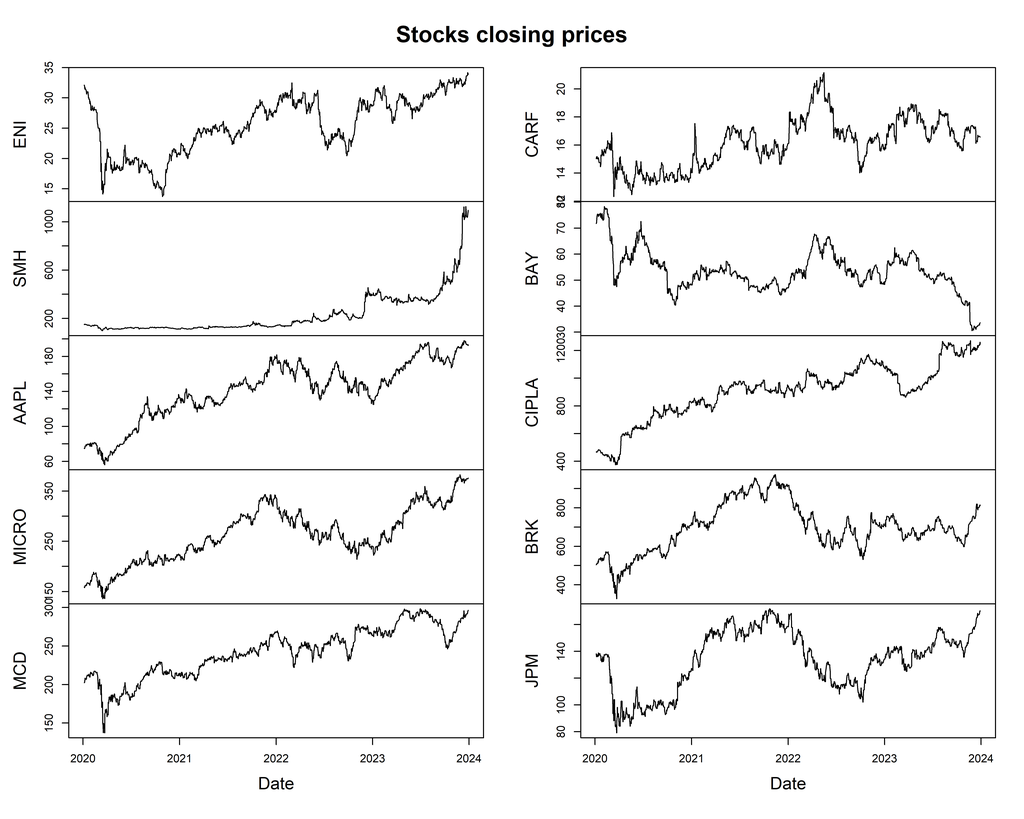

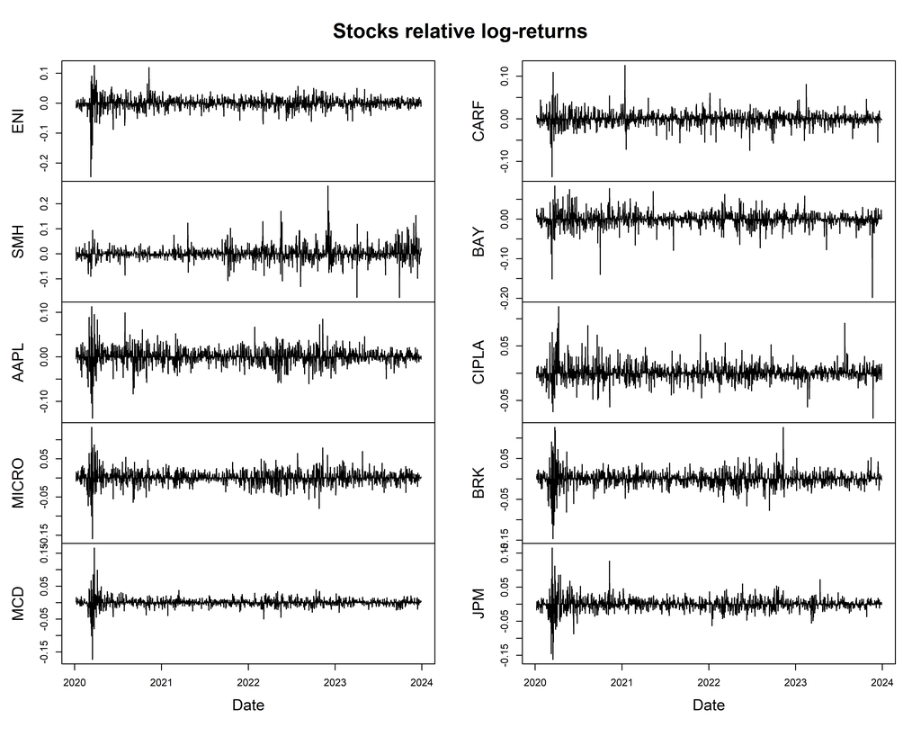

So far we have given a more sectoral interpretation, but if we focus on the countries where these stocks are based we can clearly see the very low correlation between the Asian stocks (Cipla and Sumiseki Holdings) compared to the others, probably indicating a clear sign of the little economic influence between Western and Eastern countries, on the other hand the five American stocks have a high correlation between them. This allows us to state that the geographical position also influences the correlation.

In conclusion we can claim that the distinct patterns observed across these stocks point towards a heterogeneous impact of macroeconomic conditions and sector specific events over the past four years. We can also see a pattern reflected in all stocks, which is the large variation in log-returns during the months of the global Covid-19 pandemic that greatly affected the economy.  
Considering, instead, the other years, while some stocks have thrived (possibly due to innovation, strategic positioning, or favorable market conditions) others have faced declines that could be attributable to adverse sectoral developments or operational headwinds. For instance in the case of Apple and Microsoft we can observe a truly remarkable increase in closing prices from 2020 to the present day, which is also probably attributable to the post-pandemic onset of even higher consumption of technological equipment, both at home and at work/school.

The next step of our analysis is to calculate the Pearson correlations of each stock compared to each other. In order to get these values we’ve decided to proceed as follows: - The data we’ve obtained from the first part of preprocessing gave us the opening date as 01-07-2020. However once the log-returns were calculated, given that the latter provide us with the change in the closing price of the same day compared to the previous day, we had missing data which was the log-return of the day 01-07-2020 and therefore we’ve decided to store data in a dataframe that was structured as follows: on the columns they had each stock and instead on the rows the log-returns for each day from 01-08-2020 to 12-29-2023 - Once we’ve obtained the dataframe we’ve built the correlation matrix where on the rows and columns we have the stocks in such a way that in position $(i,j)$ of the matrix there is the correlation coefficient between the stock present in row $i$ and the stock in column $j$

The following is the correlation matrix we’ve obtained:

```r
# PREPROCESSING PART 2
# Create a dataframe of the relative log-returns for each stock
# We've decided to drop the first value as the relative log-return can't be calculated for the first day
eni <- as.data.frame(eni$y[-1])
eni$dates <- rownames(eni)
smh <- as.data.frame(smh$y[-1])
smh$dates <- rownames(smh)
aapl <- as.data.frame(aapl$y[-1])
aapl$dates <- rownames(aapl)
micro <- as.data.frame(micro$y[-1])
micro$dates <- rownames(micro)
mcd <- as.data.frame(mcd$y[-1])
mcd$dates <- rownames(mcd)
carf <- as.data.frame(carf$y[-1])
carf$dates <- rownames(carf)
bay <- as.data.frame(bay$y[-1])
bay$dates <- rownames(bay)
cipla <- as.data.frame(cipla$y[-1])
cipla$dates <- rownames(cipla)
brk <- as.data.frame(brk$y[-1])
brk$dates <- rownames(brk)
jpm <- as.data.frame(jpm$y[-1])
jpm$dates <- rownames(jpm)

# Join the datasets together to get a data matrix of their relative log-returns
df <- plyr::join_all(list(eni,smh,aapl,micro,mcd,carf,bay,cipla,brk,jpm), by = 'dates', type = 'full')
df <- subset(df, select = -c(dates))
colnames(df) <- c('eni','smh','aapl','micro','mcd','carf','bay','cipla','brk','jpm')

# Print the correlation matrix between stocks
corr_mat <- cor(df)
# WIP - Prettify it
knitr::kable(corr_mat ,  caption = "Correlation Matrix")
```

Correlation Matrix

|  | eni | smh | aapl | micro | mcd | carf | bay | cipla | brk | jpm |
| --- | --- | --- | --- | --- | --- | --- | --- | --- | --- | --- |
| eni | 1.0000000 | 0.0257754 | 0.3783387 | 0.3954151 | 0.4736904 | 0.3401203 | 0.4190241 | 0.0879914 | 0.5214177 | 0.6335265 |
| smh | 0.0257754 | 1.0000000 | 0.0335782 | 0.0344277 | 0.0250207 | 0.0088331 | 0.0193337 | -0.0333613 | 0.0246866 | 0.0393933 |
| aapl | 0.3783387 | 0.0335782 | 1.0000000 | 0.7794996 | 0.5211738 | 0.1706368 | 0.2163548 | 0.1297430 | 0.6231988 | 0.4587869 |
| micro | 0.3954151 | 0.0344277 | 0.7794996 | 1.0000000 | 0.5262149 | 0.1373884 | 0.1870249 | 0.1297127 | 0.6485143 | 0.4514424 |
| mcd | 0.4736904 | 0.0250207 | 0.5211738 | 0.5262149 | 1.0000000 | 0.1916835 | 0.2612244 | 0.1685360 | 0.5981856 | 0.5931061 |
| carf | 0.3401203 | 0.0088331 | 0.1706368 | 0.1373884 | 0.1916835 | 1.0000000 | 0.3140583 | 0.0574625 | 0.2386218 | 0.2847032 |
| bay | 0.4190241 | 0.0193337 | 0.2163548 | 0.1870249 | 0.2612244 | 0.3140583 | 1.0000000 | 0.0883129 | 0.2980788 | 0.3228133 |
| cipla | 0.0879914 | -0.0333613 | 0.1297430 | 0.1297127 | 0.1685360 | 0.0574625 | 0.0883129 | 1.0000000 | 0.1258650 | 0.1514211 |
| brk | 0.5214177 | 0.0246866 | 0.6231988 | 0.6485143 | 0.5981856 | 0.2386218 | 0.2980788 | 0.1258650 | 1.0000000 | 0.6859994 |
| jpm | 0.6335265 | 0.0393933 | 0.4587869 | 0.4514424 | 0.5931061 | 0.2847032 | 0.3228133 | 0.1514211 | 0.6859994 | 1.0000000 |

There are some key observations that we have to do:

As expected, companies within the same sector show strong correlations in their stock returns, for instance Apple and Microsoft, both in the technology sector, have a high correlation (0.779), suggesting their stock prices often move in tandem, possibly due to similar market influences or technological developments impacting the sector.

On the other hand, JPMorgan has notable correlations with companies across different sectors, such as Eni (0.633), indicating that macroeconomic factors or global market sentiments might have a significant influence on these stocks. This could be due to JPMorgan’s broad exposure to various industries through its financial services.  
If we focus our attention on the energy sector, in particular on Eni, and financial services, represented by JPMorgan and BlackRock, we can see a moderate to high correlation (Eni and JPM: 0.633, Eni and BRK: 0.521): this may reflect the sensitivity of financial stocks to changes in energy prices, which can impact economic growth and inflation.

Carrefour shows lower correlations with technology and materials stocks, which aligns with the defensive nature of consumer staples during various market conditions. On the other hand, McDonald’s (consumer discretionary) has higher correlations with tech stocks, possibly due to shared consumer spending patterns and economic growth prospects.

Sumiseki Holdings has a very low correlation with most stocks, particularly with those outside its sector, like Cipla and Carrefour. This could be attributed to the materials sector’s unique dependence on commodity prices and industrial demand, as opposed to consumer or healthcare markets.

The varying degrees of correlation indicate potential for risk diversification. For instance, an investor might combine holdings in Cipla with any of the tech companies to create a portfolio that is less prone to market volatility, as indicated by the relatively low correlations.

In conclusion, from the correlation matrix we can state that it reflects both sectoral influences and broader economic factors at play. It **is crucial for constructing portfolios that can potentially mitigate risk through diversification while capitalizing on correlated movements within certain industries.**

At this point we are able to getting started building the **Pearson-based correlation graph over stocks**, which will give us a better understanding of the global correlation structure.

We need two fundamental ingredient to build it:

- **$\tau$, a specific and appropriate threshold:** a common approach is to select $\tau$ based on statistical significance of the correlation coefficients, ensuring that they are not due to chance. For financial data a stricter threshold might be chosen to focus on more robust correlations. We also need to avoid any multiplicity issue, as we perform multiple comparisons for every stock: it’s crucial to balance the desire to identify meaningful correlations with the risk of falsely identifying random relationships as significant. A conservative approach might involve setting $\tau$ at a level where the false discovery rate is controlled, possibly through adjustment methods like the **Bonferroni correction**. In particular, we’ve chosen to follow these steps:
  - Calculate the p-value for each correlation coefficient in the correlation matrix to assess their statistical significance.
  - **Apply the Bonferroni correction** in order to control the FDR due to multiple comparisons. The Bonferroni correction is based on adjusting the significance level $\alpha$ by dividing it by the number of comparisons $m$. In our scenario we have a significance level $\alpha=0.05$ and $m=45$ comparisons (a Pearson correlation for each combination of 2 stock in a group of 10 stock). In order to maintain an overall significance level of $\alpha$ we must consider $\alpha^\prime=\frac{\alpha}{m}$ as our new significance level for each individual test.
  - Finally, based on the corrected significance level $\alpha^\prime$ (so after the correction), we set **$\tau$ to be the smallest significant correlation coefficient.**
- **$C^{j_1,j_2}_n(\alpha)$:** the usual asymptotic Normal-based confidence interval at level $\alpha=0.05$ for the Pearson-correlation studied during the lessons.

Having collected these two fundamental ingredients, we now construct the graph in the following way: **we will add an edge connecting two stocks if the associated Pearson’s correlation confidence interval ($C^{j_1,j_2}_n(\alpha)$) doesn’t intersect the symmetric interval $[-\tau,\tau]$.**

```r
# There are m=45 comparisons
# Hence, starting from a level alpha=0.05, the (Bonferroni) corrected level is
m = 45
alpha = 0.05
alpha_corrected <- alpha/m # 0.001

# Get a matrix with p-values for the calculated Pearson's correlations
cor.test.p <- function(x){
    PVAL <- function(x, y) cor.test(x, y)[['p.value']]
    pvals <- outer(
      colnames(x),
      colnames(x),
      Vectorize(function(i,j) PVAL(x[,i], x[,j]))
    )
    dimnames(pvals) <- list(colnames(x), colnames(x))
    return(pvals)
}

# Get a matrix containing the lower bounds of the Confidence Intervals for Pearson's correlation at the chosen significance level
cor.test.lower <- function(x, conf){
    LOW <- function(x, y) cor.test(x, y, conf.level = conf)[['conf.int']][1]
    lower_bounds <- outer(
      colnames(x),
      colnames(x),
      Vectorize(function(i,j) LOW(x[,i], x[,j]))
    )
    dimnames(lower_bounds) <- list(colnames(x), colnames(x))
    return(lower_bounds)
}

# Get a matrix containing the upper bounds of the Confidence Intervals for Pearson's correlation at the chosen significance level
cor.test.upper <- function(x, conf){
    UP <- function(x, y) cor.test(x, y, conf.level = conf)[['conf.int']][2]
    upper_bounds <- outer(
      colnames(x),
      colnames(x),
      Vectorize(function(i,j) UP(x[,i], x[,j]))
    )
    dimnames(upper_bounds) <- list(colnames(x), colnames(x))
    return(upper_bounds)
}

# Leverage the previously defined functions to calculate the p-values and the CIs associated to the correlation coefficients
pvals <- cor.test.p(df)
lower_b <- cor.test.lower(df, conf = 1-alpha_corrected)
upper_b <- cor.test.upper(df, conf = 1-alpha_corrected)

# The threshold is the minimum correlation coefficient among the statistically significant ones
tau <- min(corr_mat[which(pvals < alpha_corrected)])

# The edges which are going to be added to the graph are those corresponding to a Pearson's correlation coefficient with a CI not intersecting the interval [-tau,tau]
edges <- (upper_b < -tau | lower_b > tau)
# Leverage the previous selection and the correlation matrix to build the adjacency matrix with correlations as weights
adj_mat <- matrix(ifelse(edges, round(corr_mat,2), 0), nrow = 10, ncol = 10)
```

Here follows the correlation graph we’ve just built. Consider that the nodes’ size represents the strength of their correlation **overall** (sum of correlation coefficients) and the nodes’ color represents their country:

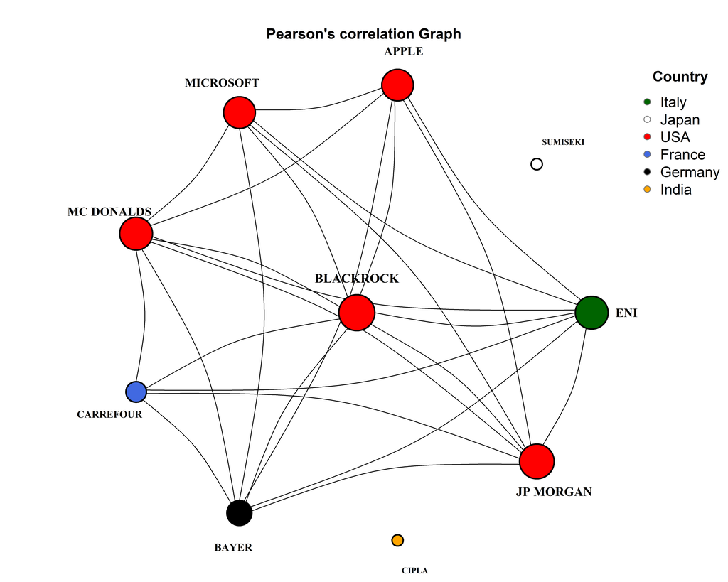

The graph confirms and strengthens all of the precedent hypothesis. Additionally, it can be noticed that **the stocks tend to be correlated when they belong to the same country**: the american stocks in our case are an example. It can be seen that the european stocks are correlated among them and with some american stocks, suggesting that the american market and the european one often share the same economic patterns and politics. Though, Carrefour is (mildly) correlated with only five stocks among them, confirming its defensive nature. The only two stocks from asian countries are correlated with no other stock, highlighting the degree of independence of their markets.

The next step of our analysis is to use the theory above and **non-parametric bootstrap** to calculate confidence intervals for the Shapley value of each stock in the portfolio.  
It is done by sampling with replacement the data from the original dataframe $B$ times and then by estimating the Shapley value for each stock (at every iteration). The number of iterations $B$ must be large, in our case 10000. The estimated Shapley values are used to calculate **percentile CIs** at level $\alpha = 0.05$.  
As the log-returns of a stock are assumed to be distributed as a *Gaussian*, we’ve estimated the Shapley values by plugging in the sample mean as an estimator of the expected value. We’ve also used the covariance matrix derived from the correlation graph to get the needed covariance values.  
As $\omega$ is a factor that represents the risk propensity (the more, the less is the risk taken), we’ve decided to compare the bootstrapped CIs obtained by considering three levels of it: 0.5,1 and 2.

```r
# Calculate percentile CIs for the Shapley Values and store them in a matrix
perc_int <- function(bootsamp, alpha){
  lows <- c(rep(NA,ncol(bootsamp)))
  ups <- c(rep(NA,ncol(bootsamp)))
  for (j in 1:ncol(bootsamp)){
    lows[j] <- unname(quantile(bootsamp[,j], alpha/2))
    ups[j] <-  unname(quantile(bootsamp[,j], 1-alpha/2))
  }
  out <- matrix(c(lows,ups), ncol = 2)
  dimnames(out) <- list(colnames(bootsamp), c('Lower Bound','Upper Bound'))
  return(out)
}

shap_ci_perc <- list()

# Bootstrap CIs for Shapley Values
B = 10000 # Number of iterations for bootstrap
n <- nrow(df)
omega <- c(0.5,1,2) # Fix the risk propensity values
set.seed(4545) # Set seed for reproducibility
for (i in 1:3){
  o <- omega[i]
  shap.B <- matrix(NA, nrow = B, ncol = ncol(df)) # Bootstrap B Shapley values for each stock
  dimnames(shap.B) <- list(1:B, colnames(df)) # Rename columns
  # Non-parametric bootstrap for Shapley Values
  for (b in 1:B){
     idx <-  sample(1:n, replace = T)
     cov_mat <- matrix(ifelse(edges, cov(df[idx,]), 0), nrow = 10, ncol = 10) # Create a covariance matrix, fixing the covariance to zero for variables not linked in the correlation graph
     for (j in 1:10){
       shap.B[b,j] <- mean(df[idx,j]) - o*sum(cov_mat[j,]) # Shapley formula, we use the sample mean as estimator of the expected value (assuming that the log-returns follow a normal distribution) and the adjacency matrix of the correlation graph to retrieve the covariance between the variables
     }
  }
  shap_ci_perc[[length(shap_ci_perc)+1]] <- perc_int(shap.B,0.05)
}

knitr::kable(shap_ci_perc[[1]] ,  caption = "Bootstrapped Confidence Intervals for the Shapley Value of each stock - omega 0.5")
```

Bootstrapped Confidence Intervals for the Shapley Value of each stock - omega 0.5

|  | Lower Bound | Upper Bound |
| --- | --- | --- |
| eni | -0.0017959 | 0.0003778 |
| smh | -0.0003889 | 0.0023929 |
| aapl | -0.0008880 | 0.0009641 |
| micro | -0.0009084 | 0.0008932 |
| mcd | -0.0009199 | 0.0005142 |
| carf | -0.0010016 | 0.0005814 |
| bay | -0.0019265 | -0.0000509 |
| cipla | -0.0001698 | 0.0013192 |
| brk | -0.0013355 | 0.0005577 |
| jpm | -0.0015152 | 0.0003911 |

```r
knitr::kable(shap_ci_perc [[2]] ,  caption = "Bootstrapped Confidence Intervals for the Shapley Value of each stock - omega 1")
```

Bootstrapped Confidence Intervals for the Shapley Value of each stock - omega 1

|  | Lower Bound | Upper Bound |
| --- | --- | --- |
| eni | -0.0026708 | -0.0001947 |
| smh | -0.0007632 | 0.0019998 |
| aapl | -0.0015359 | 0.0004328 |
| micro | -0.0015485 | 0.0003773 |
| mcd | -0.0014400 | 0.0001111 |
| carf | -0.0013576 | 0.0002822 |
| bay | -0.0024229 | -0.0004502 |
| cipla | -0.0002867 | 0.0011985 |
| brk | -0.0021107 | -0.0000851 |
| jpm | -0.0023001 | -0.0002192 |

```r
knitr::kable(shap_ci_perc[[3]] ,  caption = "Bootstrapped Confidence Intervals for the Shapley Value of each stock - omega 2")
```

Bootstrapped Confidence Intervals for the Shapley Value of each stock - omega 2

|  | Lower Bound | Upper Bound |
| --- | --- | --- |
| eni | -0.0044386 | -0.0012972 |
| smh | -0.0015082 | 0.0012252 |
| aapl | -0.0029399 | -0.0006674 |
| micro | -0.0029741 | -0.0006598 |
| mcd | -0.0026110 | -0.0005952 |
| carf | -0.0020212 | -0.0002294 |
| bay | -0.0035023 | -0.0012159 |
| cipla | -0.0004753 | 0.0009819 |
| brk | -0.0037335 | -0.0013515 |
| jpm | -0.0039207 | -0.0014202 |